# Environmental genotoxicity assessment using micronucleus test on intertidal mussel Perumytilus purpuratus. A tool for biomonitoring the Chilean coast

Catalina A. Musrri

20-06-2020

## Clear the environment

```r
rm(list = ls())
```

## Load packages

*Before loading the packages install them using *install()**

```r
library(tidyverse)
library(summarytools)
library(dplyr)
library(car)
library(pander)
library(knitr)
library(sandwich)
library(AER)
library(MASS)
```

## **Part 1:** Data inspection

In this part the dataframe was inspected in order to check the variables names and type.

1. Import data

```r
Micronucleus <- read.csv("Data/Micronucleus.csv")
```

2. Inspect structure of data frames

```r
view(dfSummary(Micronucleus))
```

## **Part 2:** Visualize differences between site and sampling

1. Generate plots

In this part the Figure 2 was created to visualize differences among sites and sampling for each nuclear abnormality.

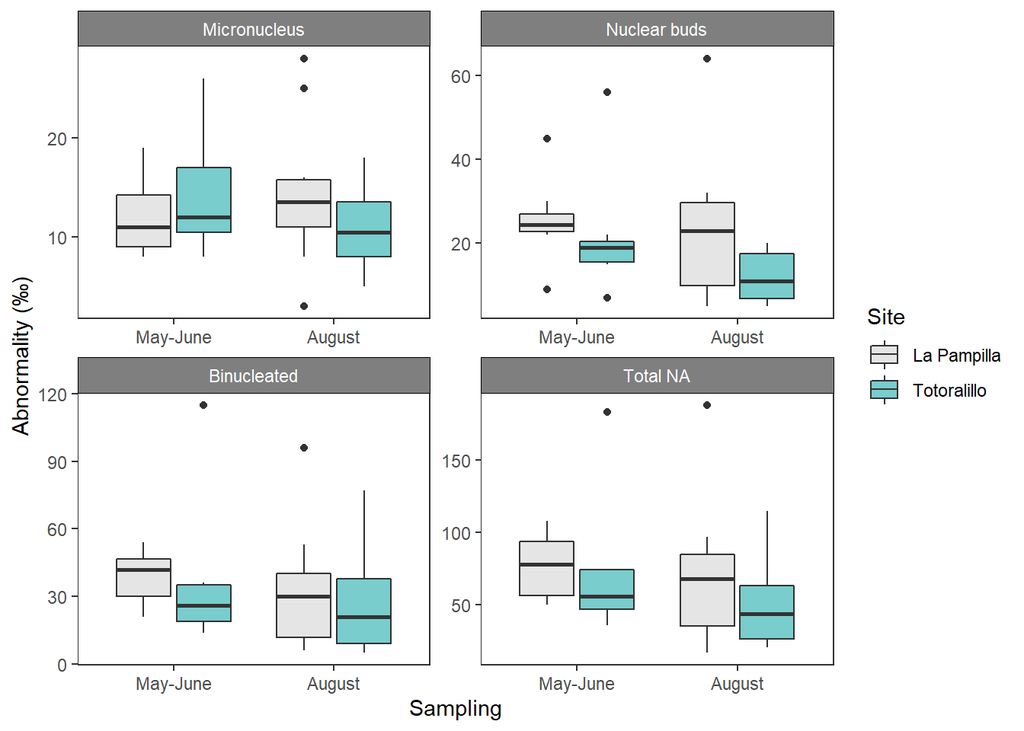

```r
#Set the right order of nuclear abnormalities in the plot
Abnormalities.labs <- c( "Micronucleus", "Binucleated","Nuclear buds", "Total NA")
names(Abnormalities.labs) <- c("MN", "Binucleated", "Nuclear_Buds", "Total_AN")
Micronucleus$Abnormality <- factor(Micronucleus$Abnormality, levels=c('MN','Nuclear_Buds','Binucleated','Total_AN'))


Micronucleus %>%
filter(Treatment == "No_treatment") %>%
ggplot(aes(x = Sampling, y = Number, fill = Site)) +
geom_boxplot()+
theme_bw() +
theme(panel.grid.major = element_line(colour = "white"),
panel.grid.minor = element_line(colour = "white")) +
labs( y="Abnormality (‰)", x="Sampling")+
facet_wrap(Abnormality ~ .,
  labeller = labeller(Abnormality = Abnormalities.labs), scales = "free", ncol=2) +
scale_fill_manual(values=c("grey90", "darkslategray3")) +
scale_x_discrete(limit = c("May-June", "August")) +
theme(strip.text.x = element_text(color = "white"),  strip.text.y = element_text(color = "white"),  strip.background = element_rect(color="black", fill="grey50", size=0.2, linetype="solid"))
```

2. Save plot in tiff format

```r
ggsave("Abnormalities.tiff", units="in", width=6, height=4, dpi=300, compression = 'lzw')
```

## **Part 3:** Statystical analysis

In part 3, data was summarized and analyzed using linear models. First, the number of replicates and the mean per group were calculates for the Table S1.

### **3a)** Summarizing results

1. Count number of replicates

```r
table1 <- Micronucleus %>%
group_by(Site, Sampling, Treatment) %>%
summarise(n_distinct(Replicate))
kable(table1)
```

| Site | Sampling | Treatment | n_distinct(Replicate) |
| --- | --- | --- | --- |
| La Pampilla | August | No_treatment | 10 |
| La Pampilla | August | Treated | 10 |
| La Pampilla | May-June | No_treatment | 8 |
| La Pampilla | May-June | Treated | 8 |
| Totoralillo | August | No_treatment | 10 |
| Totoralillo | August | Treated | 10 |
| Totoralillo | May-June | No_treatment | 7 |
| Totoralillo | May-June | Treated | 8 |

2. Calculate means for table

```r
table2 <- Micronucleus  %>%
group_by(Site, Sampling, Treatment, Abnormality) %>%
summarise(mean_a = mean(Number), sd_a = sd(Number))
kable(table2)
```

[output not shown]

### **3b)** Run linear model

1. Filter the data

```r
Micronucleus <- mutate(Micronucleus, LogNumber = log(Number)) #Create log10 column in case transformation is needed
MN_data <- Micronucleus %>%
  filter (Abnormality == "MN", Treatment == "No_treatment") #select just MN and No_treatment data
#NB
NB_data <- Micronucleus %>%
 filter (Abnormality == "Nuclear_Buds", Treatment == "No_treatment")
#BC
BC_data <- Micronucleus %>%
  filter (Abnormality == "Binucleated", Treatment == "No_treatment")
#Total NA
TotalNA_data <- Micronucleus %>%
  filter (Abnormality == "Total_AN", Treatment == "No_treatment")
```

2. Run glm

Because of the overdispersion of the data a negative binomial GLM was used to analyze differences between site and sampling for each nuclear abnormality and the total nuclear abnormalities. This was done following the guide of the UCLA: [Poisson Regression | R Data Analysis Examples](https://stats.idre.ucla.edu/r/dae/poisson-regression/)

```r
#MN
glm.MN <- glm(Number ~ Site * Sampling, family = "poisson", data = MN_data)
dispersiontest(glm.MN ,trafo=1) #Data is overdispersedin poisson glm
plot(glm.MN)
```

```r
glm.MN <- glm.nb(Number ~ Site * Sampling, data = MN_data) # Run negative binomial
summary(glm.MN) #AIC: 235.69
plot(glm.MN) # Residuals distribution looks better
```

```r
#Check results using robust standard errors
cov.glm.MN <- vcovHC(glm.MN, type="HC0")
std.err <- sqrt(diag(cov.glm.MN))
r.est1 <- cbind(Estimate= coef(glm.MN), "Robust SE" = std.err,
"Pr(>|z|)" = 2 * pnorm(abs(coef(glm.MN)/std.err), lower.tail=FALSE),
LL = coef(glm.MN) - 1.96 * std.err,
UL = coef(glm.MN) + 1.96 * std.err)
r.est1
#Check if the model fits
with(glm.MN, cbind(res.deviance = deviance, df = df.residual,
p = pchisq(deviance, df.residual, lower.tail=FALSE))) #The model fits well

#NB
glm.NB <- glm.nb(Number ~ Site * Sampling, data = NB_data) # Run negative binomial
summary(glm.NB)
plot(glm.NB) # Residuals distribution looks better
```

```r
cov.glm.NB <- vcovHC(glm.NB, type="HC0")
std.err <- sqrt(diag(cov.glm.NB))
r.est2 <- cbind(Estimate= coef(glm.NB), "Robust SE" = std.err,
"Pr(>|z|)" = 2 * pnorm(abs(coef(glm.NB)/std.err), lower.tail=FALSE),
LL = coef(glm.NB) - 1.96 * std.err,
UL = coef(glm.NB) + 1.96 * std.err)
r.est2
with(glm.NB, cbind(res.deviance = deviance, df = df.residual,
p = pchisq(deviance, df.residual, lower.tail=FALSE))) #The model fits well

#BC
glm.BC <- glm.nb(Number ~ Site * Sampling, data = BC_data) # Run negative binomial
summary(glm.BC)
plot(glm.BC) # Residuals distribution looks better
```

```r
cov.glm.BC <- vcovHC(glm.BC, type="HC0")
std.err <- sqrt(diag(cov.glm.BC))
r.est3 <- cbind(Estimate= coef(glm.BC), "Robust SE" = std.err,
"Pr(>|z|)" = 2 * pnorm(abs(coef(glm.BC)/std.err), lower.tail=FALSE),
LL = coef(glm.BC) - 1.96 * std.err,
UL = coef(glm.BC) + 1.96 * std.err)
r.est3
with(glm.BC, cbind(res.deviance = deviance, df = df.residual,
p = pchisq(deviance, df.residual, lower.tail=FALSE))) #The model fits well

#Total Na
glm.TotalNA <- glm.nb(Number ~ Site * Sampling, data = TotalNA_data) # Run negative binomial
summary(glm.TotalNA)
plot(glm.TotalNA) # Residuals distribution looks better
```

```r
cov.glm.TotalNA <- vcovHC(glm.TotalNA, type="HC0")
std.err <- sqrt(diag(cov.glm.TotalNA))
r.est4 <- cbind(Estimate= coef(glm.TotalNA), "Robust SE" = std.err,
"Pr(>|z|)" = 2 * pnorm(abs(coef(glm.TotalNA)/std.err), lower.tail=FALSE),
LL = coef(glm.TotalNA) - 1.96 * std.err,
UL = coef(glm.TotalNA) + 1.96 * std.err)
r.est4
with(glm.TotalNA, cbind(res.deviance = deviance, df = df.residual,
p = pchisq(deviance, df.residual, lower.tail=FALSE))) #The model fits well
```

MN Results

```r
kable(r.est1)
```

|  | Estimate | Robust SE | Pr(>\|z\|) | LL | UL |
| --- | --- | --- | --- | --- | --- |
| (Intercept) | 2.6672282 | 0.1553446 | 0.0000000 | 2.3627528 | 2.9717036 |
| SiteTotoralillo | -0.2969845 | 0.1983394 | 0.1343009 | -0.6857297 | 0.0917607 |
| SamplingMay-June | -0.1617023 | 0.1923309 | 0.4004878 | -0.5386708 | 0.2152663 |
| SiteTotoralillo:SamplingMay-June | 0.4606689 | 0.2740596 | 0.0927808 | -0.0764879 | 0.9978257 |

NB Results

```r
kable(r.est2)
```

|  | Estimate | Robust SE | Pr(>\|z\|) | LL | UL |
| --- | --- | --- | --- | --- | --- |
| (Intercept) | 3.1654750 | 0.2190885 | 0.0000000 | 2.7360615 | 3.5948886 |
| SiteTotoralillo | -0.6805684 | 0.2636808 | 0.0098506 | -1.1973828 | -0.1637540 |
| SamplingMay-June | 0.0732034 | 0.2543149 | 0.7734650 | -0.4252538 | 0.5716606 |
| SiteTotoralillo:SamplingMay-June | 0.5329324 | 0.3857170 | 0.1670741 | -0.2230730 | 1.2889378 |

BC Results

```r
kable(r.est3)
```

|  | Estimate | Robust SE | Pr(>\|z\|) | LL | UL |
| --- | --- | --- | --- | --- | --- |
| (Intercept) | 3.4965076 | 0.2447239 | 0.0000000 | 3.0168486 | 3.9761665 |
| SiteTotoralillo | -0.1223389 | 0.3607783 | 0.7345366 | -0.8294643 | 0.5847866 |
| SamplingMay-June | 0.1638438 | 0.2654531 | 0.5370875 | -0.3564442 | 0.6841318 |
| SiteTotoralillo:SamplingMay-June | 0.0882314 | 0.4975953 | 0.8592606 | -0.8870553 | 1.0635181 |

Total NA Results

```r
kable(r.est4)
```

|  | Estimate | Robust SE | Pr(>\|z\|) | LL | UL |
| --- | --- | --- | --- | --- | --- |
| (Intercept) | 4.2640873 | 0.2058973 | 0.0000000 | 3.8605287 | 4.6676460 |
| SiteTotoralillo | -0.3147685 | 0.2755104 | 0.2532493 | -0.8547689 | 0.2252318 |
| SamplingMay-June | 0.0748361 | 0.2257251 | 0.7402394 | -0.3675851 | 0.5172572 |
| SiteTotoralillo:SamplingMay-June | 0.2799102 | 0.3752319 | 0.4556879 | -0.4555442 | 1.0153647 |

4. Save results

```r
write.csv(r.est1, "glm_MN.csv")
write.csv(r.est2, "glm_NB.csv")
write.csv(r.est3, "glm_BC1.csv")
write.csv(r.est4, "glm_TotalNA.csv")
```

### **3c)** Linear regression size vz nuclear abnormalities

1. Check visual trends

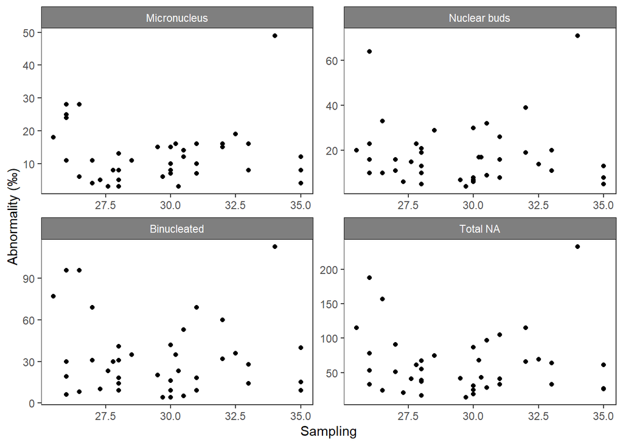

```r
Abnormalities.labs <- c( "Micronucleus", "Binucleated","Nuclear buds", "Total NA")
names(Abnormalities.labs) <- c("MN", "Binucleated", "Nuclear_Buds", "Total_AN")
Micronucleus$Abnormality <- factor(Micronucleus$Abnormality, levels=c('MN','Nuclear_Buds','Binucleated','Total_AN'))
Micronucleus %>%
filter(Sampling == "August")%>%
ggplot(aes(x = Length, y = Number)) +
geom_point()+
theme_bw() +
theme(panel.grid.major = element_line(colour = "white"),
panel.grid.minor = element_line(colour = "white")) +
labs( y="Abnormality (‰)", x="Sampling") +
facet_wrap(Abnormality ~ .,
  labeller = labeller(Abnormality = Abnormalities.labs), scales = "free", ncol=2) +
theme(strip.text.x = element_text(color = "white"),  strip.text.y = element_text(color = "white"),  strip.background = element_rect(color="black", fill="grey50", size=0.2, linetype="solid"))
```

2. Filter the data

```r
MN_length <- Micronucleus %>%
  filter (Sampling == "August", Abnormality == "MN")
NB_length <- Micronucleus %>%
  filter (Sampling == "August", Abnormality == "Nuclear_Buds")
BC_length <- Micronucleus %>%
  filter (Sampling == "August", Abnormality == "Binucleated")
NA_length <- Micronucleus %>%
  filter (Sampling == "August", Abnormality == "Total_AN")
```

3. Run linear models

Results MN

```r
#MN
MN_lm <- lm(Number ~ Length, data = MN_length)
summary(MN_lm)
```

```
##
## Call:
## lm(formula = Number ~ Length, data = MN_length)
##
## Residuals:
##    Min     1Q Median     3Q    Max
## -9.634 -5.835 -1.340  3.083 35.939
##
## Coefficients:
##             Estimate Std. Error t value Pr(>|t|)
## (Intercept)   9.1365    15.8112   0.578    0.567
## Length        0.1154     0.5325   0.217    0.830
##
## Residual standard error: 9.018 on 38 degrees of freedom
## Multiple R-squared:  0.001235,   Adjusted R-squared:  -0.02505
## F-statistic: 0.04699 on 1 and 38 DF,  p-value: 0.8295
```

```r
#NB
NB_lm <- lm(Number ~ Length, data = NB_length)
summary(MN_lm)
```

```
##
## Call:
## lm(formula = Number ~ Length, data = MN_length)
##
## Residuals:
##    Min     1Q Median     3Q    Max
## -9.634 -5.835 -1.340  3.083 35.939
##
## Coefficients:
##             Estimate Std. Error t value Pr(>|t|)
## (Intercept)   9.1365    15.8112   0.578    0.567
## Length        0.1154     0.5325   0.217    0.830
##
## Residual standard error: 9.018 on 38 degrees of freedom
## Multiple R-squared:  0.001235,   Adjusted R-squared:  -0.02505
## F-statistic: 0.04699 on 1 and 38 DF,  p-value: 0.8295
```

Results BC

```r
#BC
BC_lm <- lm(Number ~ Length, data = BC_length)
summary(BC_lm)
```

```
##
## Call:
## lm(formula = Number ~ Length, data = BC_length)
##
## Residuals:
##     Min      1Q  Median      3Q     Max
## -28.755 -19.559  -6.853   8.126  83.462
##
## Coefficients:
##             Estimate Std. Error t value Pr(>|t|)
## (Intercept)  51.7103    48.5421   1.065    0.293
## Length       -0.6521     1.6348  -0.399    0.692
##
## Residual standard error: 27.69 on 38 degrees of freedom
## Multiple R-squared:  0.00417,    Adjusted R-squared:  -0.02204
## F-statistic: 0.1591 on 1 and 38 DF,  p-value: 0.6922
```

Results Total NA

```r
#Total NA
TotalNA_lm <- lm(Number ~ Length, data = NA_length)
summary(TotalNA_lm)
```

```
##
## Call:
## lm(formula = Number ~ Length, data = NA_length)
##
## Residuals:
##    Min     1Q Median     3Q    Max
## -49.18 -32.08 -13.02  11.52 172.30
##
## Coefficients:
##             Estimate Std. Error t value Pr(>|t|)
## (Intercept)  80.2557    83.2085   0.965    0.341
## Length       -0.5751     2.8022  -0.205    0.839
##
## Residual standard error: 47.46 on 38 degrees of freedom
## Multiple R-squared:  0.001107,   Adjusted R-squared:  -0.02518
## F-statistic: 0.04211 on 1 and 38 DF,  p-value: 0.8385
```

## **Part 4**: R Session Information

In this part, information about the operating system and R packages attached during the production of this document can be found

```r
sessionInfo() %>% pander
```

**R version 4.0.1 (2020-06-06)**

**Platform:** x86_64-w64-mingw32/x64 (64-bit)

**locale:** *LC_COLLATE=English_Australia.1252*, *LC_CTYPE=English_Australia.1252*, *LC_MONETARY=English_Australia.1252*, *LC_NUMERIC=C* and *LC_TIME=English_Australia.1252*

**attached base packages:** *stats*, *graphics*, *grDevices*, *utils*, *datasets*, *methods* and *base*

**other attached packages:** *MASS(v.7.3-51.6)*, *AER(v.1.2-9)*, *survival(v.3.1-12)*, *lmtest(v.0.9-37)*, *zoo(v.1.8-8)*, *sandwich(v.2.5-1)*, *knitr(v.1.28)*, *pander(v.0.6.3)*, *car(v.3.0-8)*, *carData(v.3.0-4)*, *summarytools(v.0.9.6)*, *forcats(v.0.5.0)*, *stringr(v.1.4.0)*, *dplyr(v.1.0.0)*, *purrr(v.0.3.4)*, *readr(v.1.3.1)*, *tidyr(v.1.1.0)*, *tibble(v.3.0.1)*, *ggplot2(v.3.3.2)* and *tidyverse(v.1.3.0)*

**loaded via a namespace (and not attached):** *nlme(v.3.1-148)*, *matrixStats(v.0.56.0)*, *fs(v.1.4.1)*, *lubridate(v.1.7.9)*, *httr(v.1.4.1)*, *tools(v.4.0.1)*, *backports(v.1.1.7)*, *R6(v.2.4.1)*, *DBI(v.1.1.0)*, *colorspace(v.1.4-1)*, *withr(v.2.2.0)*, *tidyselect(v.1.1.0)*, *curl(v.4.3)*, *compiler(v.4.0.1)*, *cli(v.2.0.2)*, *rvest(v.0.3.5)*, *xml2(v.1.3.2)*, *labeling(v.0.3)*, *scales(v.1.1.1)*, *checkmate(v.2.0.0)*, *digest(v.0.6.25)*, *foreign(v.0.8-80)*, *rmarkdown(v.2.2)*, *rio(v.0.5.16)*, *base64enc(v.0.1-3)*, *pkgconfig(v.2.0.3)*, *htmltools(v.0.5.0)*, *highr(v.0.8)*, *dbplyr(v.1.4.4)*, *rlang(v.0.4.6)*, *readxl(v.1.3.1)*, *rstudioapi(v.0.11)*, *pryr(v.0.1.4)*, *generics(v.0.0.2)*, *farver(v.2.0.3)*, *jsonlite(v.1.6.1)*, *zip(v.2.0.4)*, *magrittr(v.1.5)*, *rapportools(v.1.0)*, *Formula(v.1.2-3)*, *Matrix(v.1.2-18)*, *Rcpp(v.1.0.4.6)*, *munsell(v.0.5.0)*, *fansi(v.0.4.1)*, *abind(v.1.4-5)*, *lifecycle(v.0.2.0)*, *stringi(v.1.4.6)*, *yaml(v.2.2.1)*, *plyr(v.1.8.6)*, *grid(v.4.0.1)*, *blob(v.1.2.1)*, *crayon(v.1.3.4)*, *lattice(v.0.20-41)*, *haven(v.2.3.1)*, *splines(v.4.0.1)*, *hms(v.0.5.3)*, *magick(v.2.3)*, *pillar(v.1.4.4)*, *tcltk(v.4.0.1)*, *codetools(v.0.2-16)*, *reprex(v.0.3.0)*, *glue(v.1.4.1)*, *evaluate(v.0.14)*, *data.table(v.1.12.8)*, *modelr(v.0.1.8)*, *vctrs(v.0.3.1)*, *cellranger(v.1.1.0)*, *gtable(v.0.3.0)*, *assertthat(v.0.2.1)*, *xfun(v.0.14)*, *openxlsx(v.4.1.5)*, *broom(v.0.5.6)* and *ellipsis(v.0.3.1)*